# Species, diabetes data set

## Wilcoxon Rank-Sum Test

One Wilcoxon test per taxon on relative abundances, diabetics vs. healthy within China. `log2_fc` is positive for diabetic-enriched taxa.

```r
wilcox_china <- run_wilcoxon(
  ps_rel    = china_t$rel,
  group_var = "Disease.MESH.ID",
  pos_level = "D003924",   # diabetic = numerator
  neg_level = "D006262"    # healthy  = denominator
)

wilcoxon_china_sig <- wilcox_china %>%
  filter(q_value < 0.05) %>%
  mutate(direction = ifelse(log2_fc > 0, "Sick-enriched", "Healthy-enriched")) %>%
  select(Genus, Species, direction, log2_fc, p_value, q_value) %>%
  arrange(log2_fc)

write.csv(wilcoxon_china_sig, "analysisa_sig_species_wilcox.csv")

# Top diabetic-enriched (positive log2FC)
wilcox_china %>%
  filter(q_value < 0.05) %>%
  arrange(-log2_fc) %>%
  select(Genus, Species, mean_pos, mean_neg, log2_fc, p_value, q_value) %>%
  head(10)
```

```
## # A tibble: 5 × 7
##   Genus               Species          mean_pos mean_neg log2_fc p_value q_value
##   <chr>               <chr>               <dbl>    <dbl>   <dbl>   <dbl>   <dbl>
## 1 g__Enterocloster    s__Enterocloste…  0.0121  0.000294   5.36  2.57e-4 0.0199
## 2 g__Bifidobacterium  s__Bifidobacter…  0.0161  0.00490    1.71  1.30e-3 0.0402
## 3 g__Faecalibacterium s__Faecalibacte…  0.0596  0.0875    -0.554 5.39e-4 0.0279
## 4 g__Prevotella       s__Prevotella s…  0.00817 0.0353    -2.11  1.17e-3 0.0402
## 5 g__Roseburia        s__Roseburia in…  0.00341 0.0154    -2.18  1.02e-5 0.00159
```

```r
# Top healthy-enriched (negative log2FC)
wilcox_china %>%
  filter(q_value < 0.05) %>%
  arrange(log2_fc) %>%
  select(Genus, Species, mean_pos, mean_neg, log2_fc, p_value, q_value) %>%
  head(10)
```

```
## # A tibble: 5 × 7
##   Genus               Species          mean_pos mean_neg log2_fc p_value q_value
##   <chr>               <chr>               <dbl>    <dbl>   <dbl>   <dbl>   <dbl>
## 1 g__Roseburia        s__Roseburia in…  0.00341 0.0154    -2.18  1.02e-5 0.00159
## 2 g__Prevotella       s__Prevotella s…  0.00817 0.0353    -2.11  1.17e-3 0.0402
## 3 g__Faecalibacterium s__Faecalibacte…  0.0596  0.0875    -0.554 5.39e-4 0.0279
## 4 g__Bifidobacterium  s__Bifidobacter…  0.0161  0.00490    1.71  1.30e-3 0.0402
## 5 g__Enterocloster    s__Enterocloste…  0.0121  0.000294   5.36  2.57e-4 0.0199
```

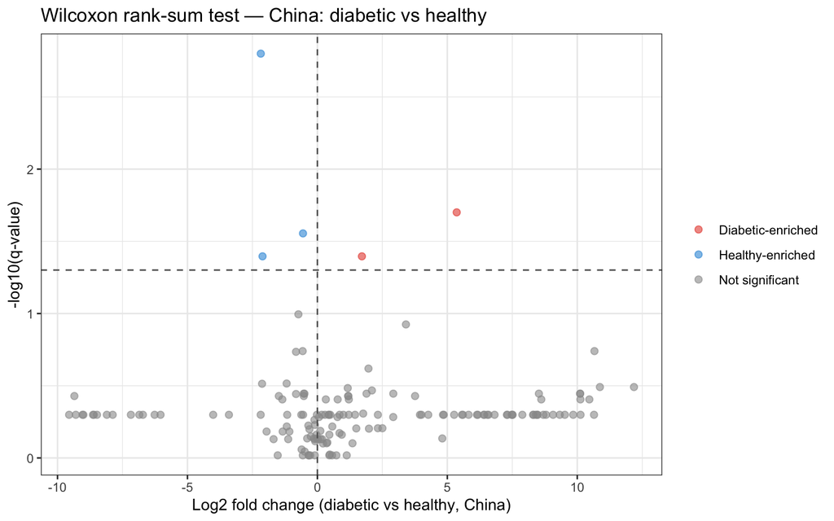

```r
# Volcano plot
wilcox_china %>%
  mutate(
    neg_log10_q = -log10(q_value),
    direction   = case_when(
      q_value < 0.05 & log2_fc > 0 ~ "Diabetic-enriched",
      q_value < 0.05 & log2_fc < 0 ~ "Healthy-enriched",
      TRUE ~ "Not significant"
    )
  ) %>%
  ggplot(aes(x = log2_fc, y = neg_log10_q, color = direction)) +
    geom_point(alpha = 0.6, size = 2) +
    scale_color_manual(values = c(
      "Diabetic-enriched" = "#E74C3C",
      "Healthy-enriched"  = "#3498DB",
      "Not significant"   = "grey60"
    )) +
    geom_hline(yintercept = -log10(0.05), linetype = "dashed", color = "grey40") +
    geom_vline(xintercept = 0,            linetype = "dashed", color = "grey40") +
    labs(x = "Log2 fold change (diabetic vs healthy, China)",
         y = "-log10(q-value)", color = NULL,
         title = "Wilcoxon rank-sum test — China: diabetic vs healthy") +
    theme_bw()
```

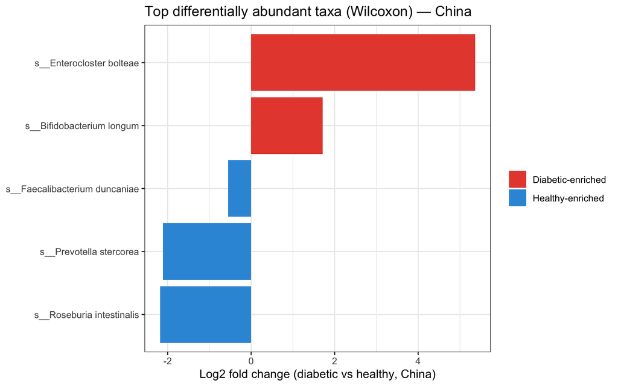

```r
# Top-taxa bar chart
bind_rows(
  wilcox_china %>% filter(q_value < 0.05) %>% arrange(-log2_fc) %>% head(10),
  wilcox_china %>% filter(q_value < 0.05) %>% arrange(log2_fc)  %>% head(10)
) %>%
  distinct() %>%
  mutate(
    direction    = ifelse(log2_fc > 0, "Diabetic-enriched", "Healthy-enriched"),
    display_name = ifelse(!is.na(Species) & Species != "", Species, Genus)
  ) %>%
  ggplot(aes(x = reorder(display_name, log2_fc), y = log2_fc, fill = direction)) +
    geom_col() +
    coord_flip() +
    scale_fill_manual(values = c(
      "Diabetic-enriched" = "#E74C3C",
      "Healthy-enriched"  = "#3498DB"
    )) +
    labs(x = NULL,
         y = "Log2 fold change (diabetic vs healthy, China)",
         fill = NULL,
         title = "Top differentially abundant taxa (Wilcoxon) — China") +
    theme_bw()
```

## GLM (with relative abundances)

```r
china_logrel <- transform_sample_counts(china_t$rel, function(x) {x <- x + 1e-9; log(x)})

rel_china <- run_clr_lm(
  ps_clr      = china_logrel,
  formula_str = "clr ~ sex + status + age + depth",
  term_filter = "statusD003924"
)

rel_china_sig <- rel_china %>%
  filter(q_value < 0.05) %>%
  mutate(direction = ifelse(estimate > 0, "Sick-enriched", "Healthy-enriched")) %>%
  select(Genus, Species, direction, estimate, std.error, statistic, p.value, q_value) %>%
  arrange(estimate)

write.csv(rel_china_sig, file = "a2_sig_species_relative.csv")

rel_china_healthy_enriched <- rel_china %>%
  select(taxon, Genus, Species, estimate, std.error, statistic, p.value, q_value) %>%
  arrange(estimate) %>%
  head(10)

rel_china_sick_enriched <- rel_china %>%
  select(taxon, Genus, Species, estimate, std.error, statistic, p.value, q_value) %>%
  arrange(-estimate) %>%
  head(10)

rel_china_healthy_enriched
```

```
## # A tibble: 10 × 8
##    taxon  Genus             Species estimate std.error statistic p.value q_value
##    <chr>  <chr>             <chr>      <dbl>     <dbl>     <dbl>   <dbl>   <dbl>
##  1 166486 g__Roseburia      s__Ros…    -2.85     0.709     -4.02 7.07e-5  0.0110
##  2 360807 g__Roseburia      s__Ros…    -2.76     0.888     -3.11 2.04e-3  0.105
##  3 853    g__Faecalibacter… s__Fae…    -2.50     1.00      -2.49 1.34e-2  0.273
##  4 310297 g__Phocaeicola    s__Pho…    -2.33     0.866     -2.69 7.54e-3  0.272
##  5 39491  g__Agathobacter   s__Aga…    -2.28     0.966     -2.36 1.90e-2  0.275
##  6 363265 g__Prevotella     s__Pre…    -1.57     0.622     -2.52 1.21e-2  0.273
##  7 165179 g__Prevotella     s__Pre…    -1.29     0.966     -1.34 1.82e-1  0.631
##  8 310298 g__Butyrivibrio_A s__But…    -1.29     0.759     -1.70 9.04e-2  0.500
##  9 729    g__Haemophilus_D  s__Hae…    -1.10     0.455     -2.41 1.62e-2  0.275
## 10 39485  g__Lachnospira    s__Lac…    -1.08     0.925     -1.17 2.44e-1  0.675
```

```r
rel_china_sick_enriched
```

```
## # A tibble: 10 × 8
##    taxon  Genus             Species estimate std.error statistic p.value q_value
##    <chr>  <chr>             <chr>      <dbl>     <dbl>     <dbl>   <dbl>   <dbl>
##  1 208479 g__Enterocloster  s__Ent…     1.72     0.515      3.34 9.35e-4  0.0724
##  2 46503  g__Ruminococcus_B s__Rum…     1.60     0.782      2.05 4.14e-2  0.401
##  3 357276 g__Phocaeicola    s__Pho…     1.56     0.908      1.72 8.67e-2  0.500
##  4 39492  g__Ruminiclostri… s__Rum…     1.39     0.528      2.64 8.77e-3  0.272
##  5 216816 g__Bifidobacteri… s__Bif…     1.30     0.672      1.93 5.47e-2  0.471
##  6 47678  g__Bacteroides    s__Bac…     1.21     0.915      1.32 1.87e-1  0.631
##  7 239935 g__Akkermansia    s__Akk…     1.16     0.539      2.15 3.20e-2  0.354
##  8 28116  g__Bacteroides    s__Bac…     1.14     0.859      1.33 1.85e-1  0.631
##  9 246787 g__Bacteroides    s__Bac…     1.08     0.609      1.77 7.69e-2  0.500
## 10 40518  g__Ruminococcoid… s__Rum…     1.06     0.920      1.15 2.51e-1  0.681
```

### Plots

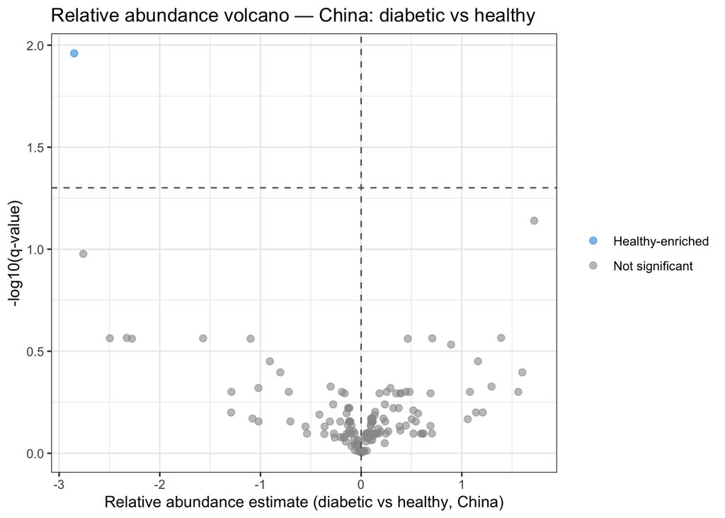

```r
plot_volcano(rel_china,
             x_label   = "Relative abundance estimate (diabetic vs healthy, China)",
             title     = "Relative abundance volcano — China: diabetic vs healthy",
             pos_label = "Diabetic-enriched",
             neg_label = "Healthy-enriched")
```

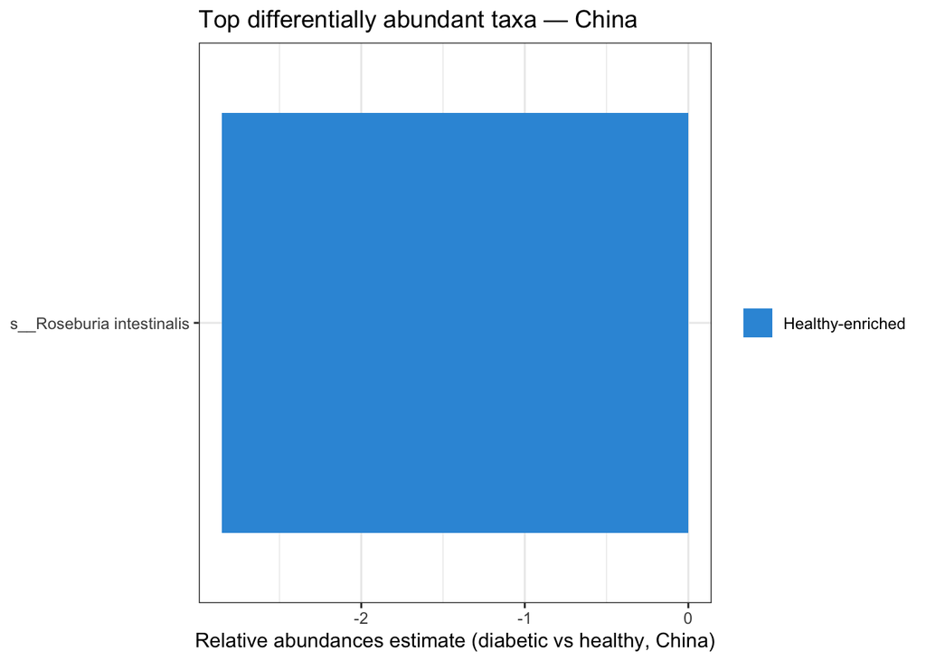

```r
plot_top_taxa(rel_china,
              x_label   = "Relative abundances estimate (diabetic vs healthy, China)",
              title     = "Top differentially abundant taxa — China",
              pos_label = "Diabetic-enriched",
              neg_label = "Healthy-enriched")
```

## Compositional Analysis — CLR Linear Model

### Running CLR + GLM

```r
clr_china <- run_clr_lm(
  ps_clr      = china_t$clr,
  formula_str = "clr ~ sex + status + age + depth",
  term_filter = "statusD003924"
)

clr_china_sig <- clr_china %>%
  filter(q_value < 0.05) %>%
  mutate(direction = ifelse(estimate > 0, "Healthy-enriched", "Sick-enriched")) %>%
  select(Genus, Species, direction, estimate, std.error, statistic, p.value, q_value) %>%
  arrange(estimate)

write.csv(clr_china_sig, "analysis2_significant_taxa.csv", row.names = FALSE)

china_healthy_enriched <- clr_china %>%
  select(taxon, Genus, Species, estimate, std.error, statistic, p.value, q_value) %>%
  arrange(estimate) %>%
  head(10)

china_sick_enriched <- clr_china %>%
  select(taxon, Genus, Species, estimate, std.error, statistic, p.value, q_value) %>%
  arrange(-estimate) %>%
  head(10)

china_healthy_enriched
```

```
## # A tibble: 10 × 8
##    taxon  Genus             Species estimate std.error statistic p.value q_value
##    <chr>  <chr>             <chr>      <dbl>     <dbl>     <dbl>   <dbl>   <dbl>
##  1 166486 g__Roseburia      s__Ros…    -2.81     0.697     -4.03 6.87e-5  0.0107
##  2 360807 g__Roseburia      s__Ros…    -2.73     0.874     -3.12 1.93e-3  0.0999
##  3 853    g__Faecalibacter… s__Fae…    -2.51     0.985     -2.54 1.14e-2  0.259
##  4 310297 g__Phocaeicola    s__Pho…    -2.29     0.850     -2.70 7.37e-3  0.259
##  5 39491  g__Agathobacter   s__Aga…    -2.26     0.949     -2.38 1.79e-2  0.273
##  6 363265 g__Prevotella     s__Pre…    -1.56     0.614     -2.53 1.17e-2  0.259
##  7 165179 g__Prevotella     s__Pre…    -1.31     0.951     -1.37 1.70e-1  0.600
##  8 310298 g__Butyrivibrio_A s__But…    -1.27     0.744     -1.70 8.96e-2  0.494
##  9 729    g__Haemophilus_D  s__Hae…    -1.08     0.448     -2.42 1.60e-2  0.273
## 10 39485  g__Lachnospira    s__Lac…    -1.06     0.906     -1.17 2.42e-1  0.671
```

```r
china_sick_enriched
```

```
## # A tibble: 10 × 8
##    taxon  Genus             Species estimate std.error statistic p.value q_value
##    <chr>  <chr>             <chr>      <dbl>     <dbl>     <dbl>   <dbl>   <dbl>
##  1 208479 g__Enterocloster  s__Ent…     1.69     0.507      3.33 9.73e-4  0.0754
##  2 46503  g__Ruminococcus_B s__Rum…     1.55     0.764      2.02 4.36e-2  0.423
##  3 357276 g__Phocaeicola    s__Pho…     1.53     0.893      1.71 8.83e-2  0.494
##  4 39492  g__Ruminiclostri… s__Rum…     1.35     0.516      2.63 9.02e-3  0.259
##  5 216816 g__Bifidobacteri… s__Bif…     1.27     0.659      1.92 5.52e-2  0.470
##  6 47678  g__Bacteroides    s__Bac…     1.17     0.895      1.30 1.93e-1  0.641
##  7 239935 g__Akkermansia    s__Akk…     1.14     0.527      2.15 3.19e-2  0.363
##  8 28116  g__Bacteroides    s__Bac…     1.11     0.844      1.32 1.89e-1  0.641
##  9 246787 g__Bacteroides    s__Bac…     1.05     0.596      1.76 7.92e-2  0.494
## 10 40518  g__Ruminococcoid… s__Rum…     1.03     0.902      1.14 2.54e-1  0.684
```

### Plots

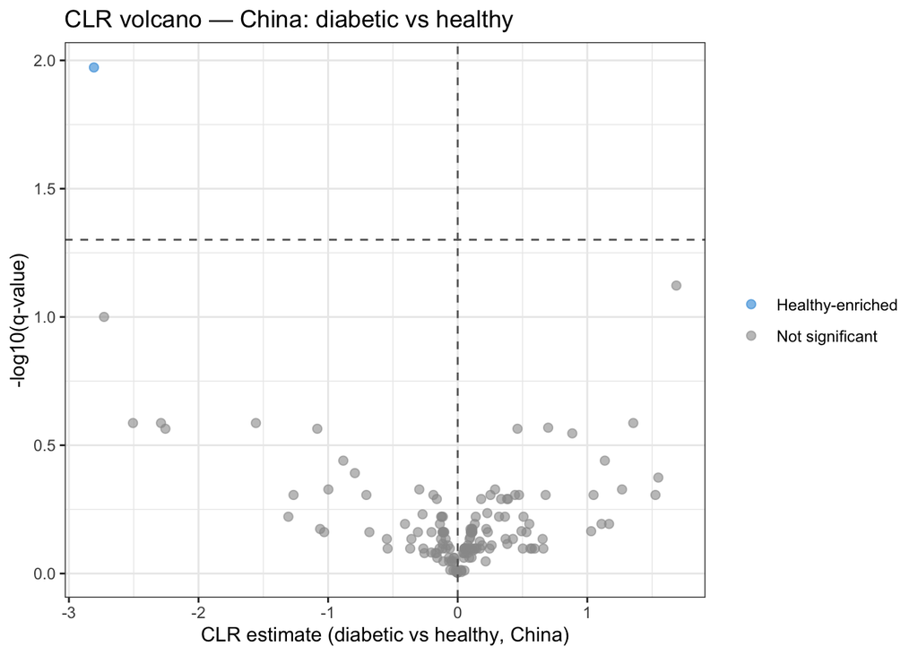

```r
plot_volcano(clr_china,
             x_label   = "CLR estimate (diabetic vs healthy, China)",
             title     = "CLR volcano — China: diabetic vs healthy",
             pos_label = "Diabetic-enriched",
             neg_label = "Healthy-enriched")
```

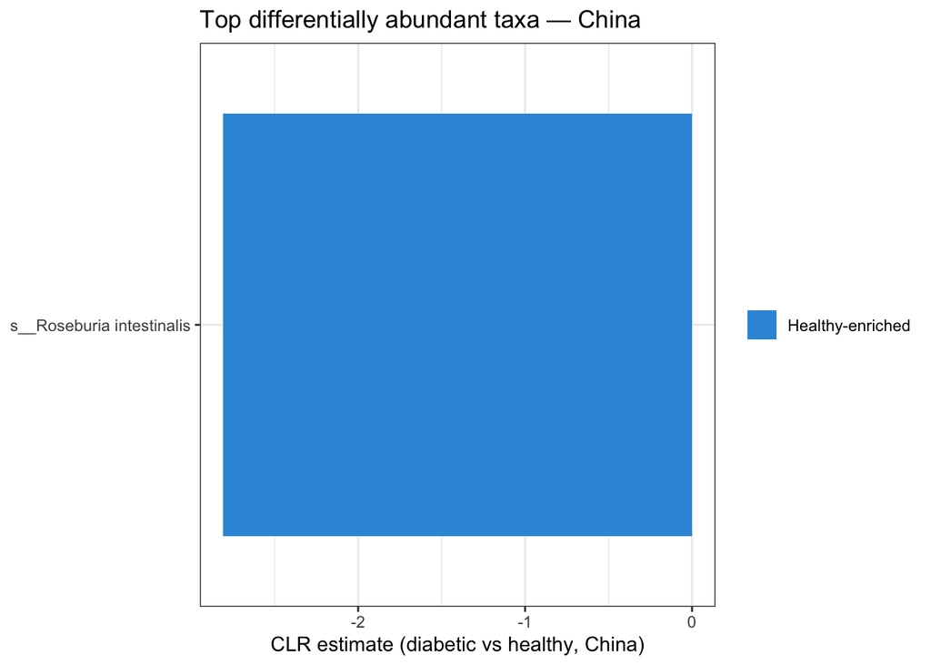

```r
plot_top_taxa(clr_china,
              x_label   = "CLR estimate (diabetic vs healthy, China)",
              title     = "Top differentially abundant taxa — China",
              pos_label = "Diabetic-enriched",
              neg_label = "Healthy-enriched")
```

## Compare three methods

```r
comp3_china <- join_three_methods(
  wilcox_res = wilcox_china,
  glm_res    = rel_china,
  clr_res    = clr_china
)

# How many taxa does each method detect?
summarise_n_sig(comp3_china)
```

```
## # A tibble: 3 × 2
##   method               n_significant
##   <chr>                        <int>
## 1 Wilcoxon                         5
## 2 GLM (rel. abundance)             1
## 3 CLR                              1
```

```r
# Consensus taxa significant in all three methods
comp3_china %>%
  filter(sig_wilcox, sig_glm, sig_clr) %>%
  mutate(direction_agreement =
           sign(wilcox_log2fc) == sign(glm_estimate) &
           sign(glm_estimate)  == sign(clr_estimate)) %>%
  select(Genus, Species, wilcox_log2fc, glm_estimate, clr_estimate,
         wilcox_q, glm_q, clr_q, direction_agreement) %>%
  arrange(clr_q)
```

```
## # A tibble: 1 × 9
##   Genus   Species wilcox_log2fc glm_estimate clr_estimate wilcox_q  glm_q  clr_q
##   <chr>   <chr>           <dbl>        <dbl>        <dbl>    <dbl>  <dbl>  <dbl>
## 1 g__Ros… s__Ros…         -2.18        -2.85        -2.81  0.00159 0.0110 0.0107
## # ℹ 1 more variable: direction_agreement <lgl>
```

[figure not shown]

```r
plot_method_heatmap(comp3_china, "Sick-enriched", "Healthy-enriched", "Comparison between three methods, analysis A")
```

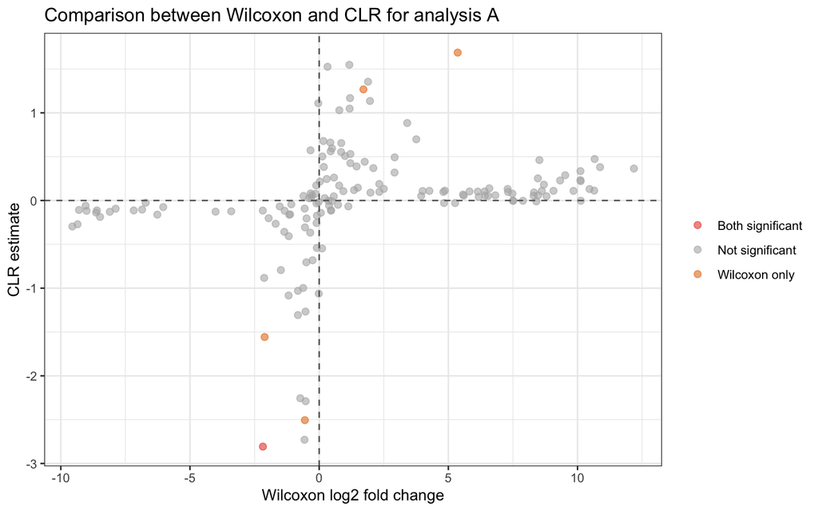

```r
plot_wilcox_clr_comparison(wilcox_china, clr_china, "Wilcoxon log2 fold change", "CLR estimate", "Comparison between Wilcoxon and CLR for analysis A")
```

## Constrained Ordination — RDA

Within China, the CLR matrix is constrained by disease status, sex, age, and sequencing depth (country is constant so it is omitted).

```r
rda_china_out <- run_rda(
  ps_clr      = china_t$clr,
  formula_str = "Disease.MESH.ID + Sex + as.numeric(Host.age) + as.numeric(Nr..reads.sequenced)",
  covariates  = c("Disease.MESH.ID", "Sex", "Host.age", "Nr..reads.sequenced")
)
```

```
## Samples removed due to NAs: 0
## Samples retained: 359
```

```r
anova(rda_china_out$rda, permutations = 999)
```

```
## Permutation test for rda under reduced model
## Permutation: free
## Number of permutations: 999
##
## Model: rda(formula = clr_clean ~ Disease.MESH.ID + Sex + as.numeric(Host.age) + as.numeric(Nr..reads.sequenced), data = meta_clean)
##           Df Variance      F Pr(>F)
## Model      4    41.93 1.7337  0.001 ***
## Residual 354  2140.64
## ---
## Signif. codes:  0 '***' 0.001 '**' 0.01 '*' 0.05 '.' 0.1 ' ' 1
```

```r
anova(rda_china_out$rda, by = "term", permutations = 999)
```

```
## Permutation test for rda under reduced model
## Terms added sequentially (first to last)
## Permutation: free
## Number of permutations: 999
##
## Model: rda(formula = clr_clean ~ Disease.MESH.ID + Sex + as.numeric(Host.age) + as.numeric(Nr..reads.sequenced), data = meta_clean)
##                                  Df Variance      F Pr(>F)
## Disease.MESH.ID                   1    18.90 3.1262  0.001 ***
## Sex                               1     9.19 1.5199  0.028 *
## as.numeric(Host.age)              1     7.29 1.2057  0.165
## as.numeric(Nr..reads.sequenced)   1     6.55 1.0829  0.326
## Residual                        354  2140.64
## ---
## Signif. codes:  0 '***' 0.001 '**' 0.01 '*' 0.05 '.' 0.1 ' ' 1
```

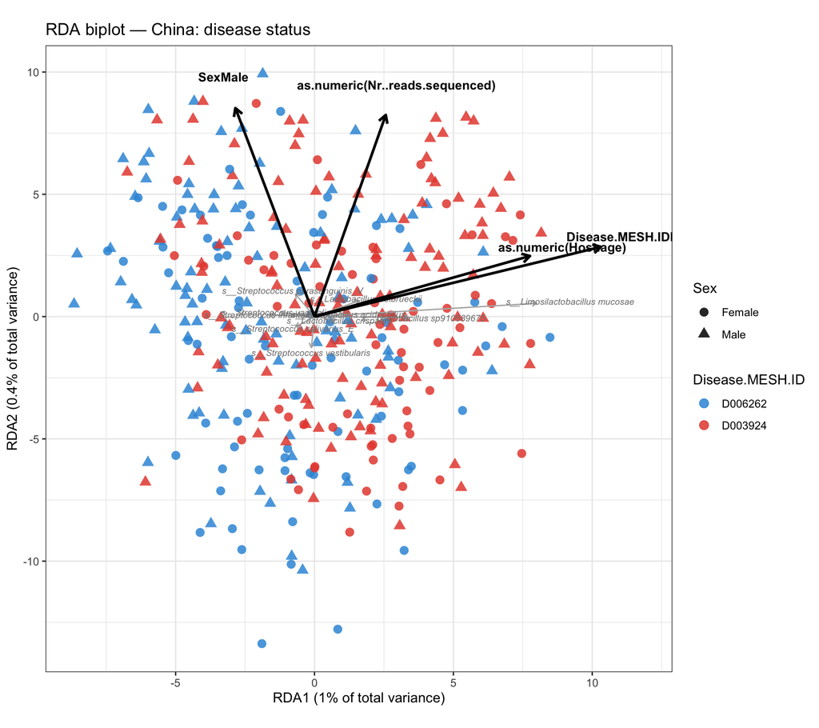

```r
plot_rda_biplot(
  rda_obj      = rda_china_out$rda,
  meta_df      = rda_china_out$meta,
  color_var    = "Disease.MESH.ID",
  shape_var    = "Sex",
  color_values = c("D003924" = "#E74C3C", "D006262" = "#3498DB"),
  shape_values = c("Female" = 16, "Male" = 17),
  title        = "RDA biplot — China: disease status"
)
```

### RDA vs CLR

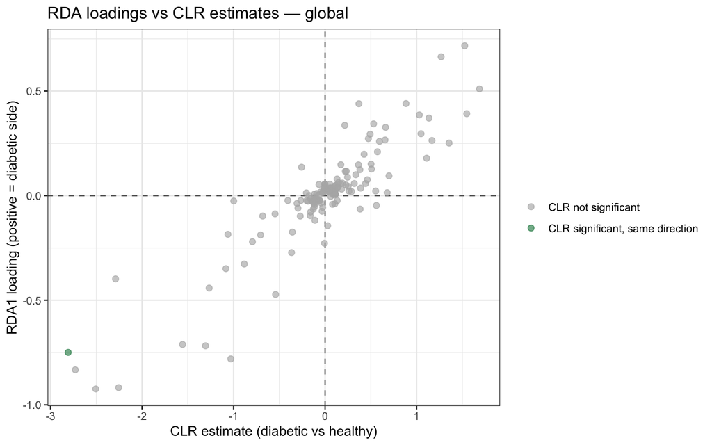

```r
# Sign of RDA1 is arbitrary; orient so that the diabetic group has positive RDA1
rda1_scores_china <- scores(rda_china_out$rda, display = "sites")[, "RDA1"]
rda1_sign_china <- ifelse(
  mean(rda1_scores_china[rda_china_out$meta$Disease.MESH.ID == "D003924"], na.rm = TRUE) >=
  mean(rda1_scores_china[rda_china_out$meta$Disease.MESH.ID == "D006262"], na.rm = TRUE),
  1, -1
)

comp_china <- compare_rda_clr(
  rda_obj  = rda_china_out$rda,
  clr_res  = clr_china,
  tax_df   = as(tax_table(global_t$clr), "matrix") %>% as.data.frame(),
  rda1_sign = rda1_sign_china
)

plot_rda_clr_comparison(
  comp_china,
  x_label = "CLR estimate (diabetic vs healthy)",
  y_label = "RDA1 loading (positive = diabetic side)",
  title   = "RDA loadings vs CLR estimates — global"
)
```

```r
comp_china %>%
  arrange(desc(abs(rda1_loading))) %>%
  select(Genus.x, rda1_loading, clr_estimate, clr_q, direction_agreement) %>%
  head(5)
```

```
## # A tibble: 5 × 5
##   Genus.x             rda1_loading clr_estimate  clr_q direction_agreement
##   <chr>                      <dbl>        <dbl>  <dbl> <lgl>
## 1 g__Faecalibacterium       -0.924        -2.51 0.259  TRUE
## 2 g__Agathobacter           -0.918        -2.26 0.273  TRUE
## 3 g__Roseburia              -0.832        -2.73 0.0999 TRUE
## 4 g__Phocaeicola            -0.780        -1.03 0.690  TRUE
## 5 g__Roseburia              -0.749        -2.81 0.0107 TRUE
```

# Analysis 3: East vs. West — Geographical Differences in Diabetics

**Question:** Among diabetic individuals only, is there a geographical difference in gut microbiome composition between Western and Chinese (Eastern) populations?

## Visualisation

### Barplot (relative abundance, n = 50 sample)

[figure not shown]

```r
ps_species_europe  <- subset_samples(ps_we, Country == "Europe")
ps_species_asia  <- subset_samples(ps_we, Country == "China")
ps_species_europe <- sample_ps(ps_species_europe, size = min(15, nsamples(ps_species_europe)))
ps_species_asia <- sample_ps(ps_species_asia, size = min(15, nsamples(ps_species_asia)))

we_species_sampled <- merge_phyloseq(ps_species_asia, ps_species_europe)


ps_species_we  <- tax_glom(we_t$rel, taxrank = "Species")
we_species_sampled <- sample_ps(ps_species_we, size = min(50, nsamples(ps_species_we)))

plot_bar(we_species_sampled, fill = "Species") +
  facet_nested(~ Country, scales = "free_x") +
  labs(title = "Relative abundance by geography (diabetics only)") +
  theme(axis.text.x = element_blank())
```

## Alpha Diversity

```r
alpha_we <- make_alpha_df(ps_we, we_t$pa)
```

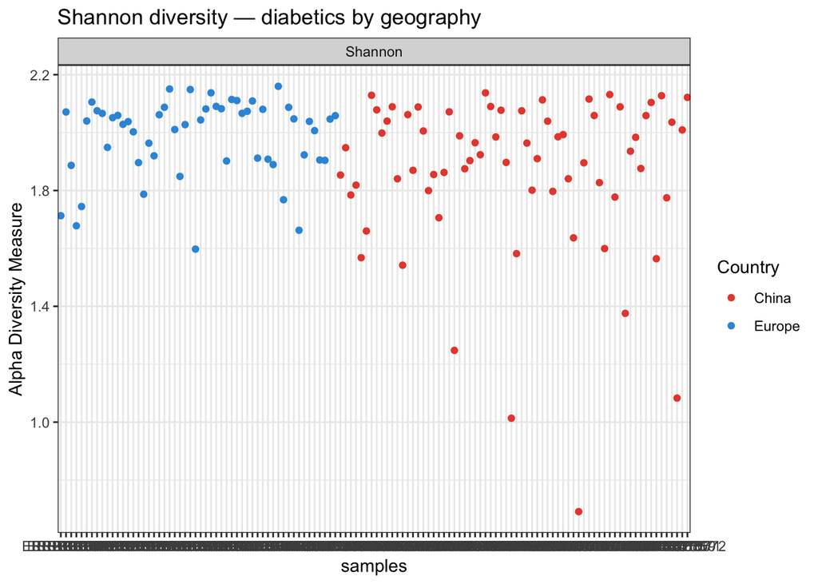

```r
plot_richness(ps_we, measures = "Shannon", color = "Country") +
  scale_color_manual(values = c("China" = "#E74C3C", "Europe" = "#3498DB")) +
  labs(title = "Shannon diversity — diabetics by geography") +
  theme_bw()
```

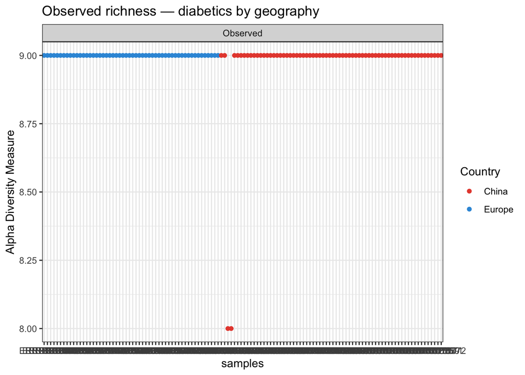

```r
plot_richness(we_t$pa, measures = "Observed", color = "Country") +
  scale_color_manual(values = c("China" = "#E74C3C", "Europe" = "#3498DB")) +
  labs(title = "Observed richness — diabetics by geography") +
  theme_bw()
```

```r
run_kruskal(alpha_we, "Shannon", "Country")
```

```
##                            Variable Chi_squared df    P_value
## Kruskal-Wallis chi-squared  Country    6.589192  1 0.01025997
```

```r
run_pairwise_wilcoxon(alpha_we, "Shannon", "Country")
```

```
## # A tibble: 1 × 5
##   Variable Comparison      P_value_adj Group1 Group2
##   <chr>    <chr>                 <dbl> <chr>  <chr>
## 1 Country  Europe vs China      0.0103 Europe China
```

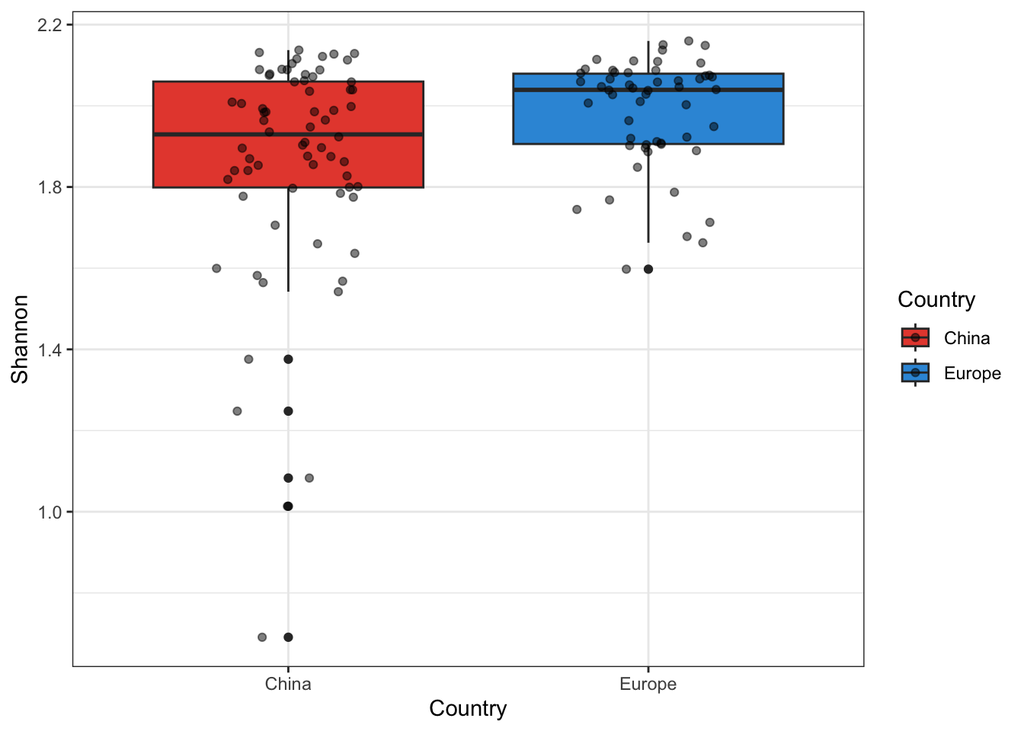

```r
ggplot(alpha_we, aes(x = Country, y = Shannon, fill = Country)) +
  geom_boxplot() +
  geom_jitter(width = 0.2, alpha = 0.5) +
  theme_bw() +
  scale_fill_manual(values = c("#E74C3C", "#3498DB"))
```

### Sequencing depth vs. Shannon

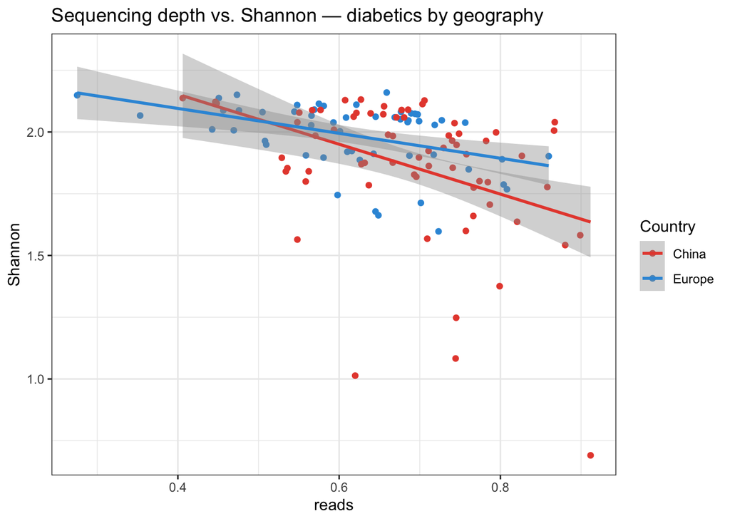

```r
alpha_we$reads <- sample_sums(ps_we)[alpha_we$sample_id]

ggplot(alpha_we, aes(x = reads, y = Shannon, color = Country)) +
  geom_point() + geom_smooth(method = "lm") +
  scale_color_manual(values = c("China" = "#E74C3C", "Europe" = "#3498DB")) +
  labs(title = "Sequencing depth vs. Shannon — diabetics by geography") +
  theme_bw()
```

```r
cor.test(alpha_we$reads, alpha_we$Shannon, method = "spearman")
```

```
##
##  Spearman's rank correlation rho
##
## data:  alpha_we$reads and alpha_we$Shannon
## S = 448554, p-value = 2.84e-08
## alternative hypothesis: true rho is not equal to 0
## sample estimates:
##        rho
## -0.4822302
```

## Beta Diversity — PERMANOVA

### Calculating the Bray-Curtis distances and the Jaccard distances

```r
bray_dist <- distance(
  ps_we,
  method = "bray"
)

jaccard_dist <- distance(
  we_t$pa,
  method = "jaccard"
)
```

### PCoA — Bray-Curtis

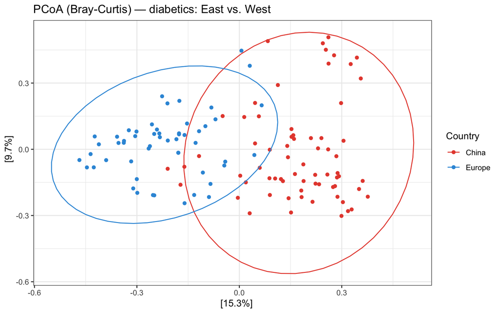

```r
bray_we <- distance(we_t$rel, method = "bray")
ord_we  <- ordinate(we_t$rel, method = "PCoA", distance = bray_we)

plot_ordination(we_t$rel, ord_we, type = "samples", color = "Country") +
    stat_ellipse(aes(color = Country),
               type = "norm",    # or "t" for robust ellipses
               level = 0.95) +   # 95% confidence ellipse
  scale_color_manual(values = c("China" = "#E74C3C", "Europe" = "#3498DB")) +
  labs(title = "PCoA (Bray-Curtis) — diabetics: East vs. West") +
  theme_bw()
```

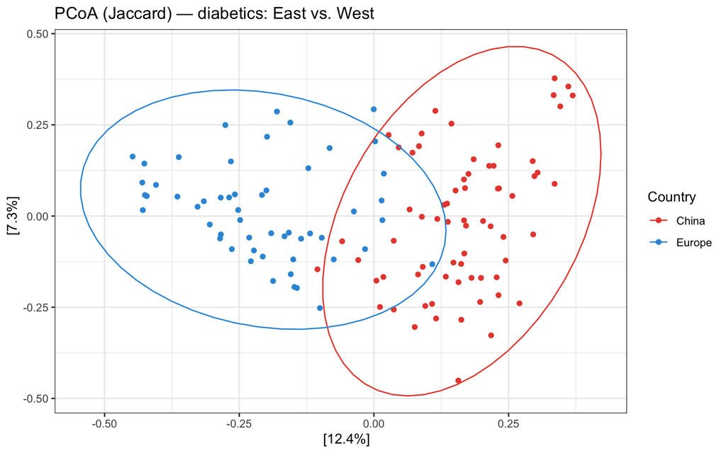

```r
jaccard_we <- distance(we_t$pa, method = "jaccard")
ordj_we  <- ordinate(we_t$pa, method = "PCoA", distance = jaccard_we)

plot_ordination(we_t$pa, ordj_we, type = "samples", color = "Country") +
    stat_ellipse(aes(color = Country),
               type = "norm",    # or "t" for robust ellipses
               level = 0.95) +   # 95% confidence ellipse
  scale_color_manual(values = c("China" = "#E74C3C", "Europe" = "#3498DB")) +
  labs(title = "PCoA (Jaccard) — diabetics: East vs. West") +
  theme_bw()
```

### NMDS based on Bray-Curtis distance

NMDS is another commonly used ordination method in ecology and microbiome analysis. Unlike PCoA, it focuses on preserving the rank order of distances rather than the distances themselves.

```r
we_nmds <- ordinate(
  we_t$rel,
  method = "NMDS",
  distance = "bray"
)
```

```
## *** Best solution was not repeated -- monoMDS stopping criteria:
##      2: no. of iterations >= maxit
##     18: stress ratio > sratmax
```

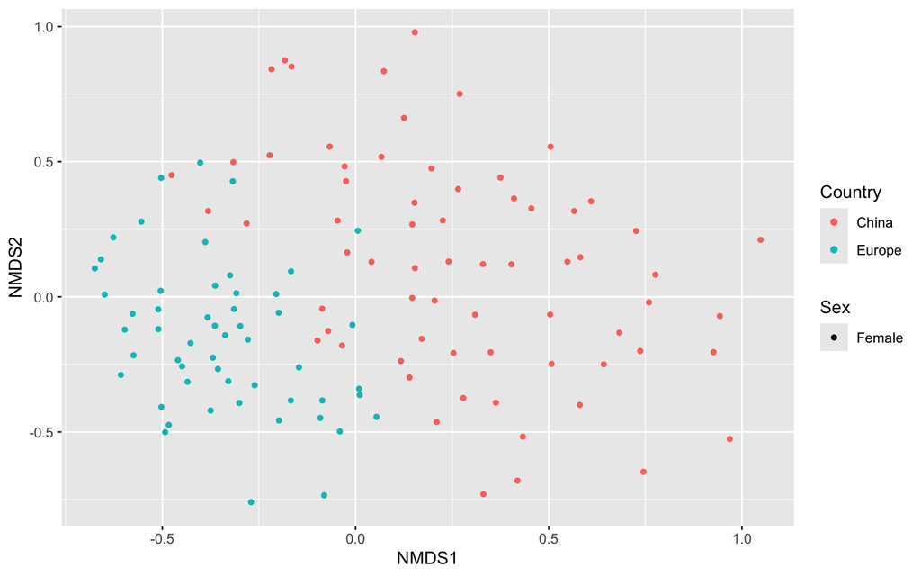

```r
plot_ordination(
  we_t$rel,
  we_nmds,
  type = "samples",
  color = "Country",
  shape = "Sex"
)
```

### PERMANOVA + Dispersion

```r
sample_df_we <- sample_data(we_t$rel) %>% data.frame()

adonis2(bray_we ~ Country,
        data = sample_df_we, permutations = 999)
```

```
## Permutation test for adonis under reduced model
## Permutation: free
## Number of permutations: 999
##
## adonis2(formula = bray_we ~ Country, data = sample_df_we, permutations = 999)
##           Df SumOfSqs      R2      F Pr(>F)
## Model      1    4.918 0.11074 14.943  0.001 ***
## Residual 120   39.495 0.88926
## Total    121   44.413 1.00000
## ---
## Signif. codes:  0 '***' 0.001 '**' 0.01 '*' 0.05 '.' 0.1 ' ' 1
```

```r
adonis2(bray_we ~ Nr..reads.sequenced,
        data = sample_df_we, permutations = 999)
```

```
## Permutation test for adonis under reduced model
## Permutation: free
## Number of permutations: 999
##
## adonis2(formula = bray_we ~ Nr..reads.sequenced, data = sample_df_we, permutations = 999)
##           Df SumOfSqs      R2      F Pr(>F)
## Model      1    0.705 0.01588 1.9358  0.011 *
## Residual 120   43.708 0.98412
## Total    121   44.413 1.00000
## ---
## Signif. codes:  0 '***' 0.001 '**' 0.01 '*' 0.05 '.' 0.1 ' ' 1
```

```r
disp_we <- betadisper(bray_we, sample_df_we$Country)
anova(disp_we)
```

```
## Analysis of Variance Table
##
## Response: Distances
##            Df  Sum Sq  Mean Sq F value    Pr(>F)
## Groups      1 0.26046 0.260458  46.703 3.659e-10 ***
## Residuals 120 0.66923 0.005577
## ---
## Signif. codes:  0 '***' 0.001 '**' 0.01 '*' 0.05 '.' 0.1 ' ' 1
```

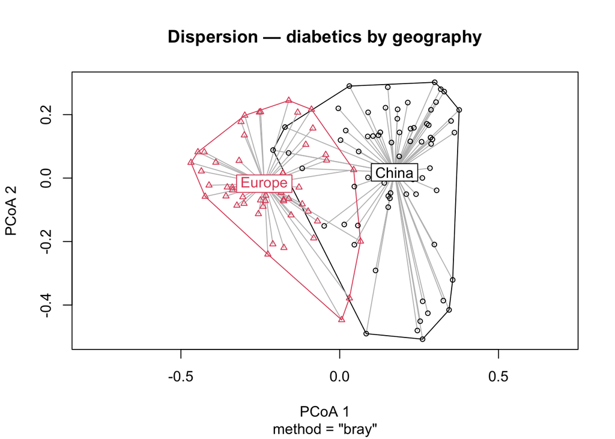

```r
plot(disp_we, main = "Dispersion — diabetics by geography")
```

```r
sample_df2_we <- sample_data(we_t$pa) %>% data.frame()

adonis2(jaccard_we ~ Country,
        data = sample_df2_we, permutations = 999)
```

```
## Permutation test for adonis under reduced model
## Permutation: free
## Number of permutations: 999
##
## adonis2(formula = jaccard_we ~ Country, data = sample_df2_we, permutations = 999)
##           Df SumOfSqs      R2      F Pr(>F)
## Model      1    4.296 0.09233 12.207  0.001 ***
## Residual 120   42.228 0.90767
## Total    121   46.524 1.00000
## ---
## Signif. codes:  0 '***' 0.001 '**' 0.01 '*' 0.05 '.' 0.1 ' ' 1
```

```r
disp_we <- betadisper(jaccard_we, sample_df2_we$Country)
anova(disp_we)
```

```
## Analysis of Variance Table
##
## Response: Distances
##            Df  Sum Sq  Mean Sq F value    Pr(>F)
## Groups      1 0.10331 0.103306  24.492 2.461e-06 ***
## Residuals 120 0.50616 0.004218
## ---
## Signif. codes:  0 '***' 0.001 '**' 0.01 '*' 0.05 '.' 0.1 ' ' 1
```

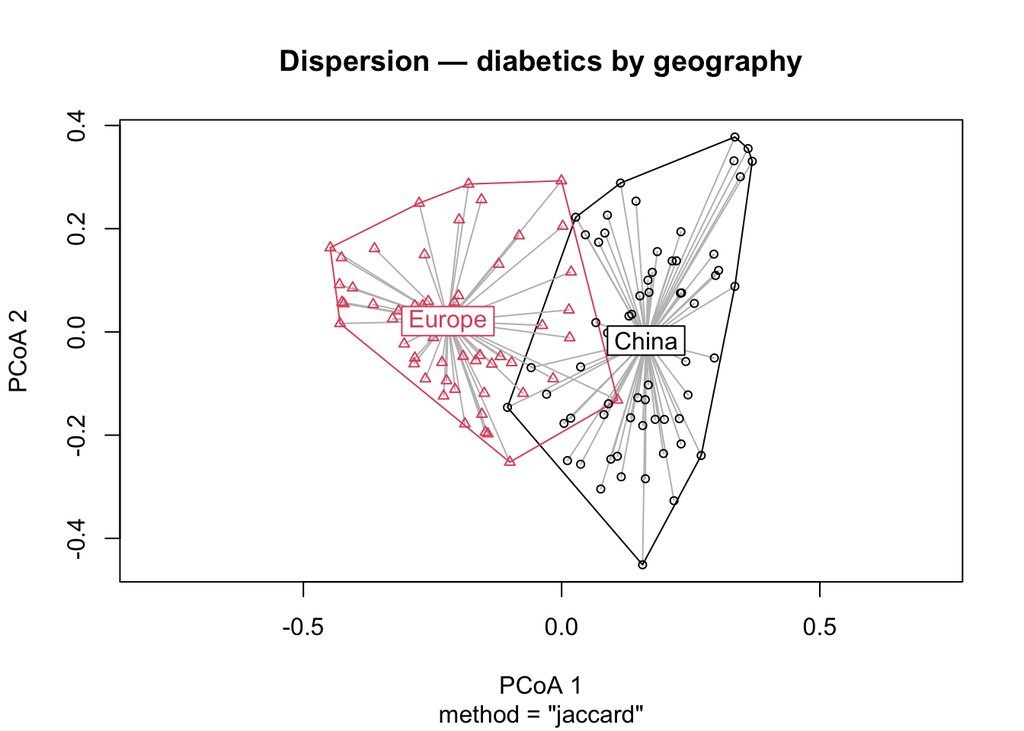

```r
plot(disp_we, main = "Dispersion — diabetics by geography")
```

## Wilcoxon Rank-Sum Test

One Wilcoxon test per taxon on relative abundances, Europe vs. China within diabetics. `log2_fc` is positive for Europe-enriched taxa.

```r
wilcox_we <- run_wilcoxon(
  ps_rel    = we_t$rel,
  group_var = "Country",
  pos_level = "Europe",   # Europe = numerator
  neg_level = "China"     # China  = denominator
)

wilcoxon_we_sig <- wilcox_we %>%
  filter(q_value < 0.05) %>%
  mutate(direction = ifelse(log2_fc > 0, "Europe-enriched", "China-enriched")) %>%
  select(Genus, Species, direction, log2_fc, p_value, q_value) %>%
  arrange(log2_fc)

write.csv(wilcoxon_we_sig, "analysisb_sig_species_wilcox.csv")

# Top Europe-enriched (positive log2FC)
wilcox_we %>%
  filter(q_value < 0.05) %>%
  arrange(-log2_fc) %>%
  select(Genus, Species, mean_pos, mean_neg, log2_fc, p_value, q_value) %>%
  head(10)
```

```
## # A tibble: 10 × 7
##    Genus              Species         mean_pos mean_neg log2_fc  p_value q_value
##    <chr>              <chr>              <dbl>    <dbl>   <dbl>    <dbl>   <dbl>
##  1 g__Anaerobutyricum s__Anaerobutyr…  0.0363  0          15.1  2.77e-11 1.64e-9
##  2 g__Butyrivibrio_A  s__Butyrivibri…  0.0191  0          14.2  1.10e- 2 4.62e-2
##  3 g__Holdemanella    s__Holdemanell…  0.0173  0          14.1  2.35e- 4 2.52e-3
##  4 g__W3P20-009       s__W3P20-009 s…  0.0170  0          14.1  1.11e- 3 8.17e-3
##  5 g__Blautia_A       s__Blautia_A o…  0.0116  0          13.5  1.07e- 4 1.40e-3
##  6 g__Bariatricus     s__Bariatricus…  0.0105  0          13.4  2.35e- 4 2.52e-3
##  7 g__Collinsella     s__Collinsella…  0.00752 0          12.9  2.39e- 3 1.41e-2
##  8 g__Blautia_A       s__Blautia_A s…  0.0576  0.000298    7.59 1.12e-11 1.33e-9
##  9 g__Dorea_A         s__Dorea_A amy…  0.0229  0.000240    6.58 1.25e- 6 2.95e-5
## 10 g__Dialister       s__Dialister i…  0.0456  0.00250     4.19 3.37e- 8 1.33e-6
```

```r
# Top China-enriched (negative log2FC)
wilcox_we %>%
  filter(q_value < 0.05) %>%
  arrange(log2_fc) %>%
  select(Genus, Species, mean_pos, mean_neg, log2_fc, p_value, q_value) %>%
  head(10)
```

```
## # A tibble: 10 × 7
##    Genus              Species          mean_pos mean_neg log2_fc p_value q_value
##    <chr>              <chr>               <dbl>    <dbl>   <dbl>   <dbl>   <dbl>
##  1 g__Bacteroides     s__Bacteroides …  0        0.0539   -15.7  1.52e-6 2.99e-5
##  2 g__Bifidobacterium s__Bifidobacter…  0        0.0333   -15.0  9.63e-3 4.37e-2
##  3 g__Ruminococcus_B  s__Ruminococcus…  0        0.0104   -13.3  1.25e-3 8.20e-3
##  4 g__Parabacteroides s__Parabacteroi…  0        0.00780  -12.9  9.63e-3 4.37e-2
##  5 g__Bacteroides     s__Bacteroides …  0.00133  0.0318    -4.58 9.84e-4 7.99e-3
##  6 g__Phocaeicola     s__Phocaeicola …  0.00142  0.0305    -4.42 1.02e-3 7.99e-3
##  7 g__Alistipes       s__Alistipes pu…  0.00423  0.0518    -3.61 1.76e-5 2.59e-4
##  8 g__Bacteroides     s__Bacteroides …  0.00238  0.0227    -3.25 1.22e-3 8.20e-3
##  9 g__Bacteroides     s__Bacteroides …  0.00200  0.0184    -3.20 2.02e-3 1.25e-2
## 10 g__Bacteroides     s__Bacteroides …  0.00435  0.0263    -2.59 4.53e-3 2.23e-2
```

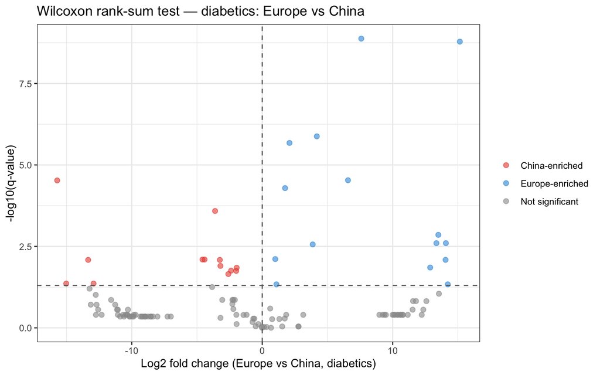

```r
# Volcano plot
wilcox_we %>%
  mutate(
    neg_log10_q = -log10(q_value),
    direction   = case_when(
      q_value < 0.05 & log2_fc > 0 ~ "Europe-enriched",
      q_value < 0.05 & log2_fc < 0 ~ "China-enriched",
      TRUE ~ "Not significant"
    )
  ) %>%
  ggplot(aes(x = log2_fc, y = neg_log10_q, color = direction)) +
    geom_point(alpha = 0.6, size = 2) +
    scale_color_manual(values = c(
      "Europe-enriched" = "#3498DB",
      "China-enriched"  = "#E74C3C",
      "Not significant" = "grey60"
    )) +
    geom_hline(yintercept = -log10(0.05), linetype = "dashed", color = "grey40") +
    geom_vline(xintercept = 0,            linetype = "dashed", color = "grey40") +
    labs(x = "Log2 fold change (Europe vs China, diabetics)",
         y = "-log10(q-value)", color = NULL,
         title = "Wilcoxon rank-sum test — diabetics: Europe vs China") +
    theme_bw()
```

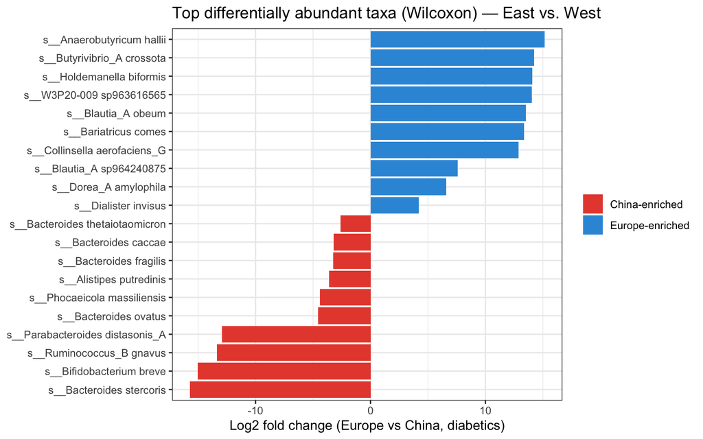

```r
# Top-taxa bar chart
bind_rows(
  wilcox_we %>% filter(q_value < 0.05) %>% arrange(-log2_fc) %>% head(10),
  wilcox_we %>% filter(q_value < 0.05) %>% arrange(log2_fc)  %>% head(10)
) %>%
  distinct() %>%
  mutate(
    direction    = ifelse(log2_fc > 0, "Europe-enriched", "China-enriched"),
    display_name = ifelse(!is.na(Species) & Species != "", Species, Genus)
  ) %>%
  ggplot(aes(x = reorder(display_name, log2_fc), y = log2_fc, fill = direction)) +
    geom_col() +
    coord_flip() +
    scale_fill_manual(values = c(
      "Europe-enriched" = "#3498DB",
      "China-enriched"  = "#E74C3C"
    )) +
    labs(x = NULL,
         y = "Log2 fold change (Europe vs China, diabetics)",
         fill = NULL,
         title = "Top differentially abundant taxa (Wilcoxon) — East vs. West") +
    theme_bw()
```

## GLM on relative abundance

```r
# 1. Run GLM on relative abundances for Analysis 3
we_logrel <- transform_sample_counts(we_t$rel, function(x) {x <- x + 1e-9; log(x)})


rel_we <- run_clr_lm(
  ps_clr      = we_t$rel,
  formula_str = "clr ~ country + depth",
  term_filter = "countryEurope"
)


rel_we_sig <- rel_we %>%
  filter(q_value < 0.05) %>%
  mutate(direction = ifelse(estimate > 0, "Healthy-enriched", "Sick-enriched")) %>%
  select(Genus, Species, direction, estimate, std.error, statistic, p.value, q_value) %>%
  arrange(estimate)

write.csv(rel_we_sig, file = "a3_sig_species_relative.csv")

rel_we_china_enriched <- rel_we %>%
  select(taxon, Genus, Species, estimate, std.error, statistic, p.value, q_value) %>%
  arrange(estimate) %>%
  head(10)

rel_we_europe_enriched <- rel_we %>%
  select(taxon, Genus, Species, estimate, std.error, statistic, p.value, q_value) %>%
  arrange(-estimate) %>%
  head(10)

rel_we_china_enriched
```

```
## # A tibble: 10 × 8
##    taxon  Genus             Species estimate std.error statistic p.value q_value
##    <chr>  <chr>             <chr>      <dbl>     <dbl>     <dbl>   <dbl>   <dbl>
##  1 46506  g__Bacteroides    s__Bac…  -0.0556   0.0130      -4.28 3.78e-5 6.38e-4
##  2 28117  g__Alistipes      s__Ali…  -0.0504   0.0133      -3.77 2.52e-4 3.41e-3
##  3 562    g__Escherichia    s__Esc…  -0.0465   0.0166      -2.80 6.02e-3 3.74e-2
##  4 165179 g__Prevotella     s__Pre…  -0.0397   0.0290      -1.37 1.74e-1 3.96e-1
##  5 1685   g__Bifidobacteri… s__Bif…  -0.0381   0.0172      -2.21 2.87e-2 1.21e-1
##  6 28116  g__Bacteroides    s__Bac…  -0.0342   0.0105      -3.25 1.48e-3 1.25e-2
##  7 357276 g__Phocaeicola    s__Pho…  -0.0338   0.0157      -2.16 3.29e-2 1.34e-1
##  8 821    g__Phocaeicola    s__Pho…  -0.0338   0.00974     -3.47 7.23e-4 7.76e-3
##  9 204516 g__Phocaeicola    s__Pho…  -0.0310   0.0108      -2.86 5.03e-3 3.30e-2
## 10 818    g__Bacteroides    s__Bac…  -0.0210   0.00949     -2.22 2.86e-2 1.21e-1
```

```r
rel_we_europe_enriched
```

```
## # A tibble: 10 × 8
##    taxon  Genus            Species estimate std.error statistic  p.value q_value
##    <chr>  <chr>            <chr>      <dbl>     <dbl>     <dbl>    <dbl>   <dbl>
##  1 39491  g__Agathobacter  s__Aga…   0.114    0.0207       5.49 2.33e- 7 8.33e-6
##  2 40518  g__Ruminococcoi… s__Rum…   0.0703   0.0155       4.54 1.37e- 5 3.23e-4
##  3 457412 g__Blautia_A     s__Bla…   0.0581   0.00833      6.97 1.89e-10 2.23e-8
##  4 853    g__Faecalibacte… s__Fae…   0.0507   0.0145       3.49 6.80e- 4 7.76e-3
##  5 218538 g__Dialister     s__Dia…   0.0416   0.00764      5.45 2.82e- 7 8.33e-6
##  6 39488  g__Anaerobutyri… s__Ana…   0.0323   0.00499      6.48 2.21e- 9 1.30e-7
##  7 751585 g__Coprococcus   s__Cop…   0.0308   0.0114       2.70 7.87e- 3 4.64e-2
##  8 88431  g__Dorea_A       s__Dor…   0.0203   0.00463      4.39 2.50e- 5 4.91e-4
##  9 1680   g__Bifidobacter… s__Bif…   0.0191   0.0109       1.76 8.18e- 2 2.51e-1
## 10 1735   g__Holdemanella  s__Hol…   0.0181   0.00552      3.27 1.40e- 3 1.25e-2
```

### Plots

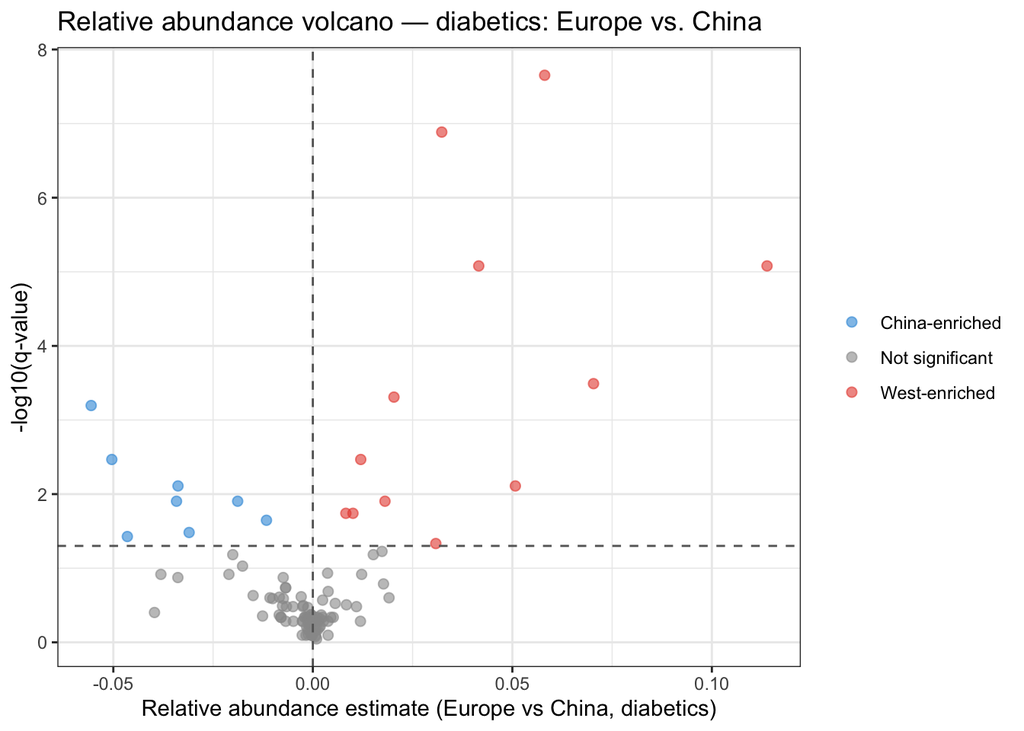

```r
plot_volcano(rel_we,
             x_label   = "Relative abundance estimate (Europe vs China, diabetics)",
             title     = "Relative abundance volcano — diabetics: Europe vs. China",
             pos_label = "West-enriched",
             neg_label = "China-enriched")
```

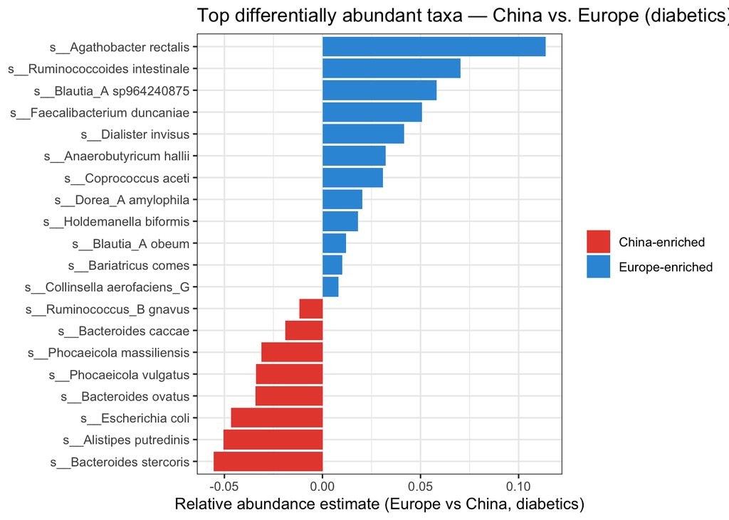

```r
plot_top_taxa(rel_we,
              x_label   = "Relative abundance estimate (Europe vs China, diabetics)",
              title     = "Top differentially abundant taxa — China vs. Europe (diabetics)",
              pos_label = "Europe-enriched",
              neg_label = "China-enriched",
              pos_color = "#3498DB",
              neg_color = "#E74C3C")
```